# Teacher Turnover: EDA

Galileu Kim

9/25/2019

The goal of this exploratory data analysis is to characterize the structure of teacher turnover in Brazil. Teacher turnover is a chronic issue in municipalities across Brazil, the question is where it is concentrated, if it varies over time and what are its consequences for student learning. The data employed are the Brazilian school census collected annually from 2007 to 2016. I adopt a broader definition of turnover than commonly adopted in labor economics, and calculate a turnover index adapted from Pereira Junior and Oliveira (2016):

$$\text{turnover}_{sjt} = \frac{\text{exit}_{jt} + \text{entry}_{sjt}}{N_{sjt} + N_{sjt-1}}$$
for school $s$ in municipality $j$ at year $t$, where

$$\text{entry}_{sjt} := \sum_{i\in\mathcal{I}_{sjt}}^{N_{sjt}}\mathbb{1}\{i\notin\mathcal{I}_{sjt-1}\}$$

and

$$\text{exit}_{sjt} := \sum_{i\in\mathcal{I}_{sjt-1}}^{N_{sjt-1}}\mathbb{1}\{i\notin\mathcal{I}_{sjt}\}$$

The index ranges from 0 to 1, with 0 denoting no turnover (no entry and no exits) and 1 the converse.

I decompose exit and entry into three different teacher flows:

# Descriptive statistics

Teacher turnover in Brazil is pervasive. Note that the higher the value of the index, the greater the turnover observed.

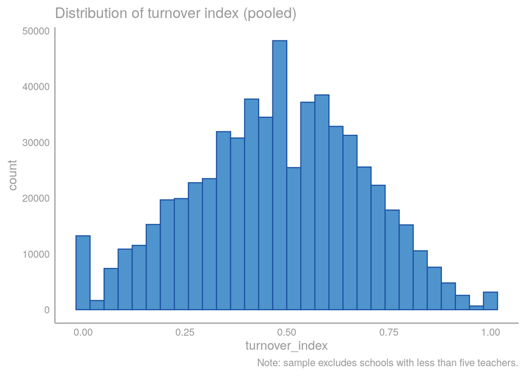

Teacher turnover follows regional patterns.

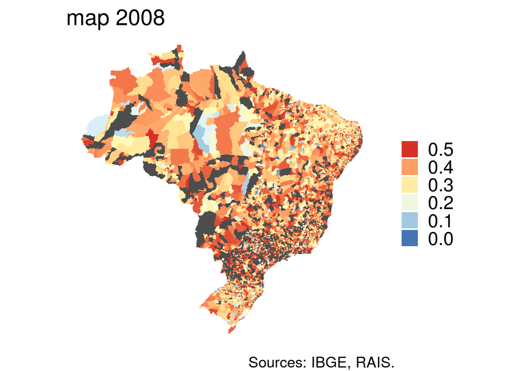

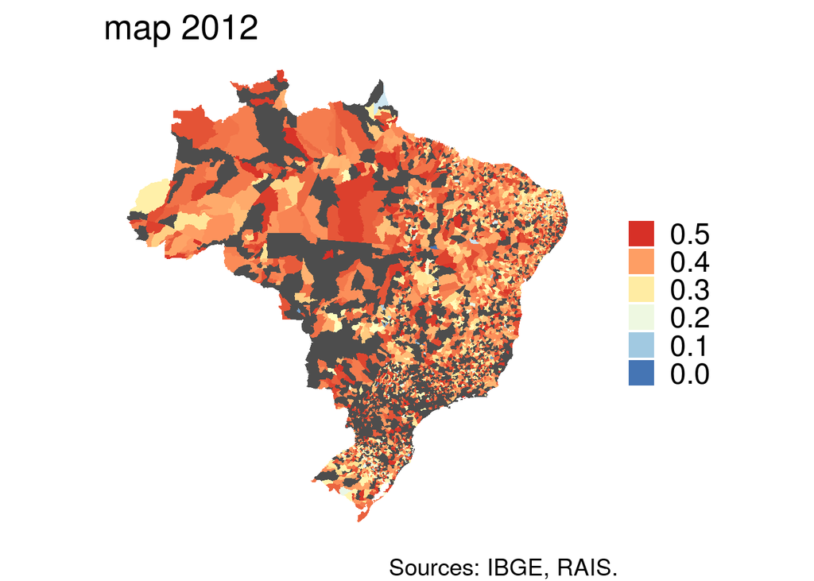

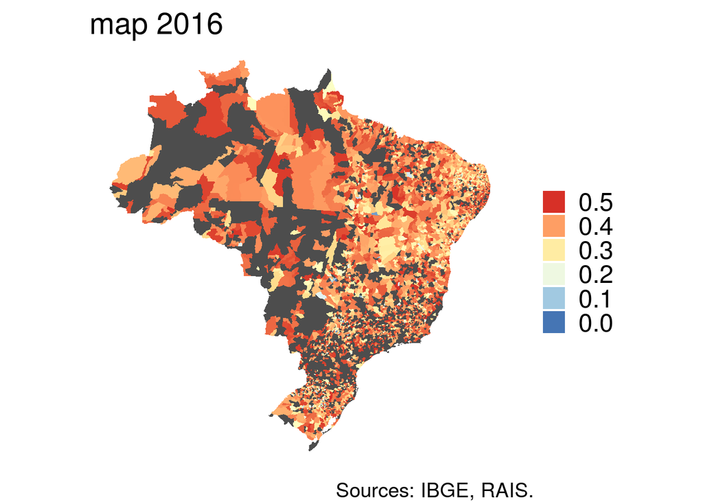

# Correlations

I now explore some potential correlations between turnover index and a set of variables that could a prior help explain variation in it. The first set is demographic.

## Demographic

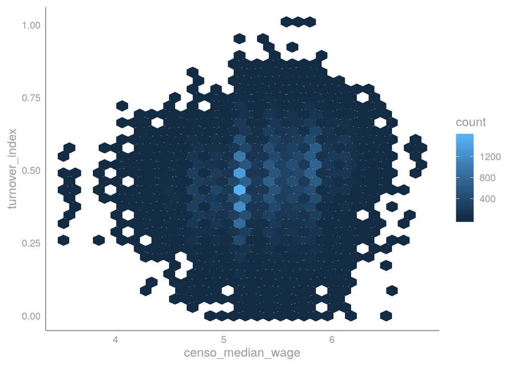

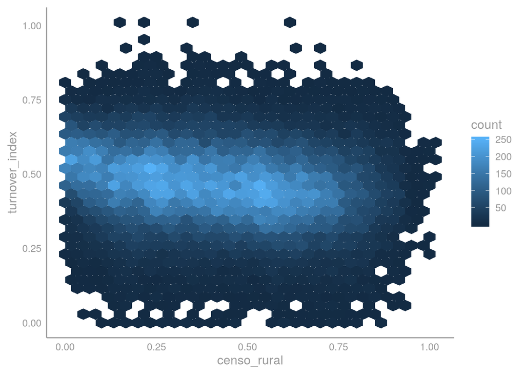

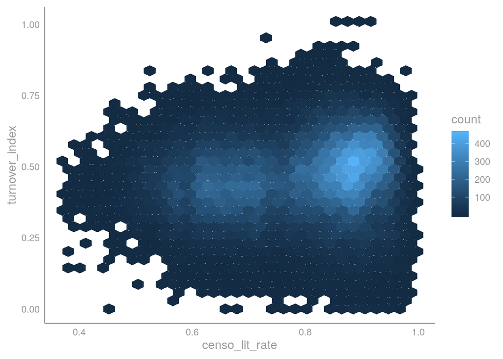

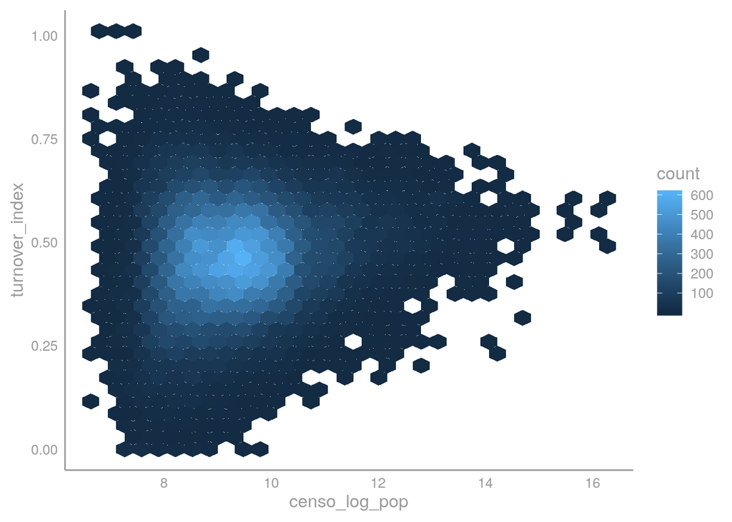

## Political variables

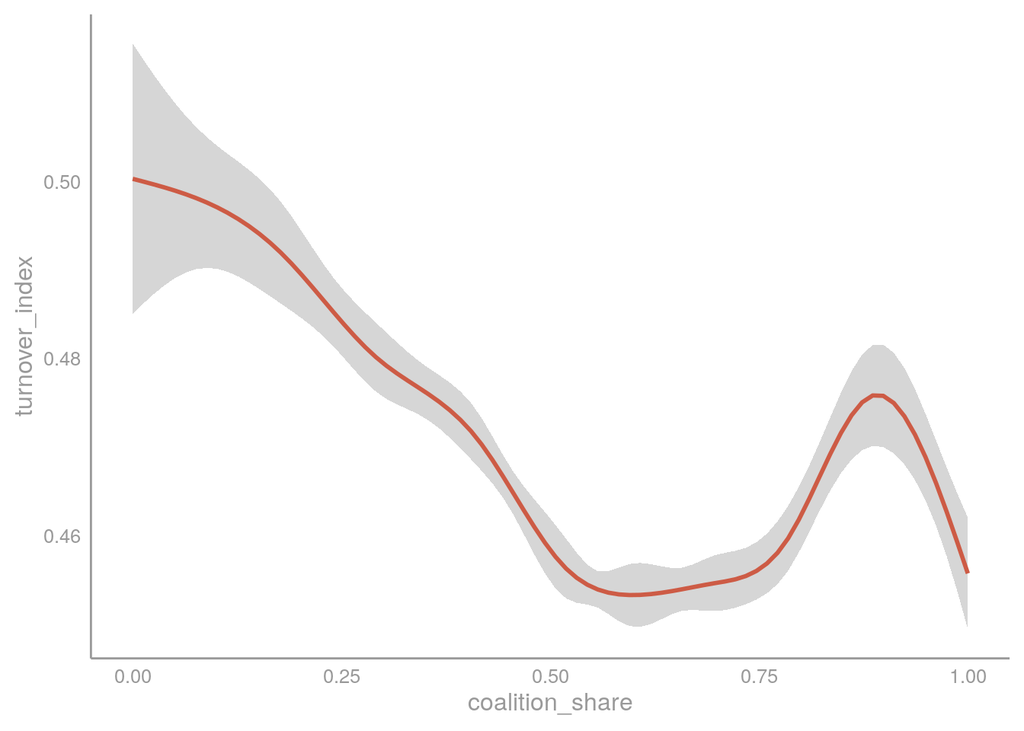

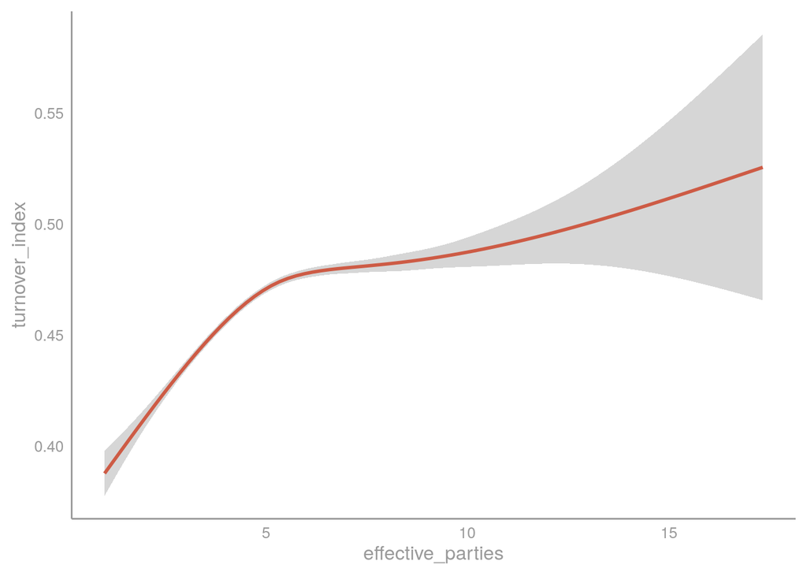

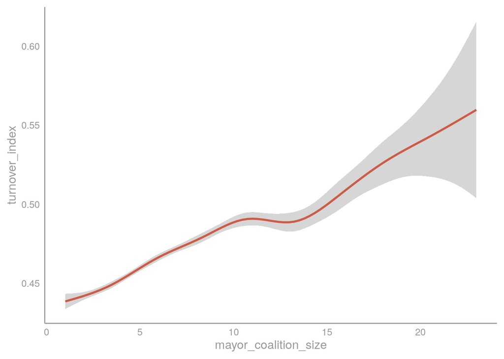

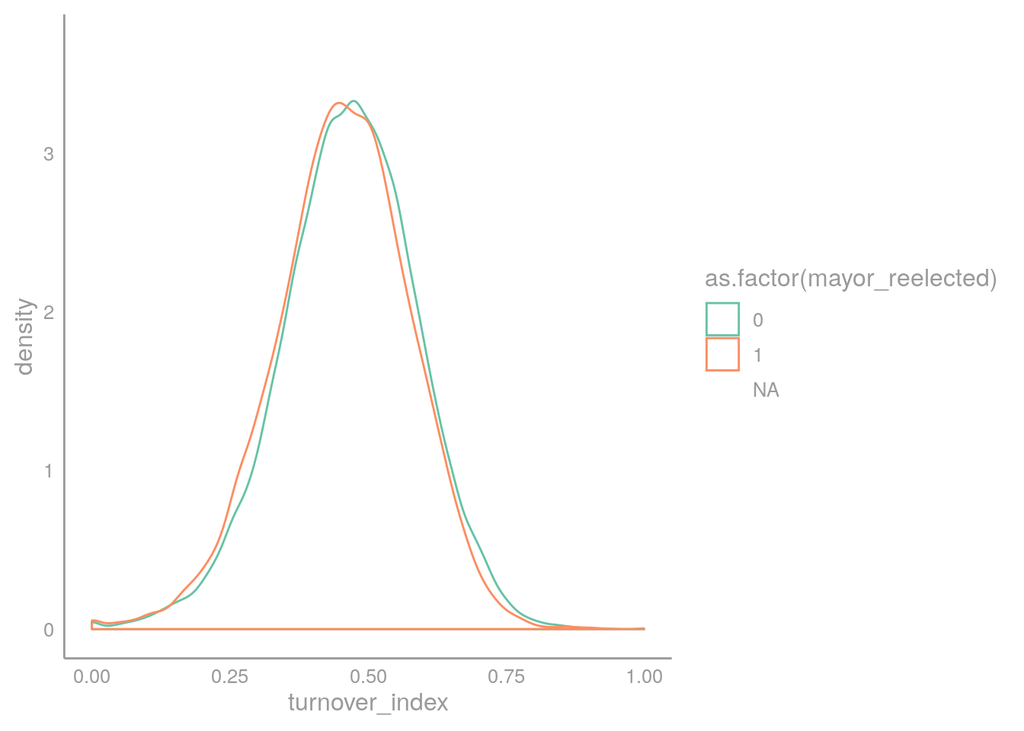

A similar pattern holds for teacher turnover as the one observed for turnover in other areas. Note that there is a negative correlation between coalition share and teacher turnover, similar to what I had found in previous analyses of staff turnover. As the number of effective parties and the size of coalition increase, there is greater turnover.

# Linear fit

Teacher turnover could be associated with a host of variables. I now explore the potential relationships between turnover and the political vars identified above, while controling for demographic covariates.

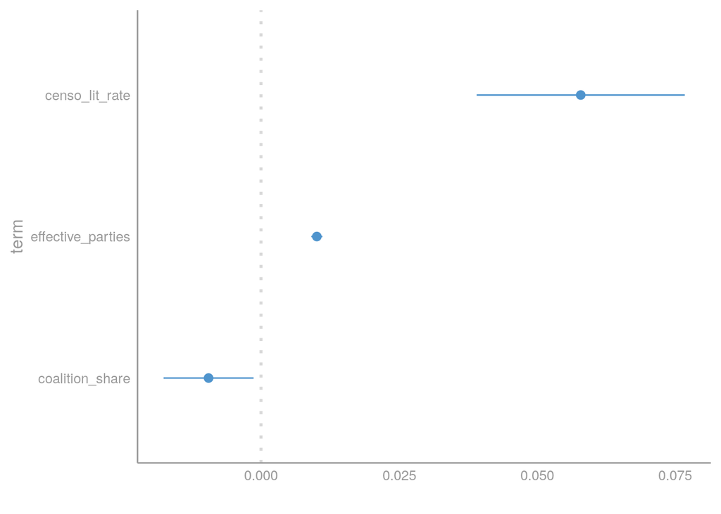

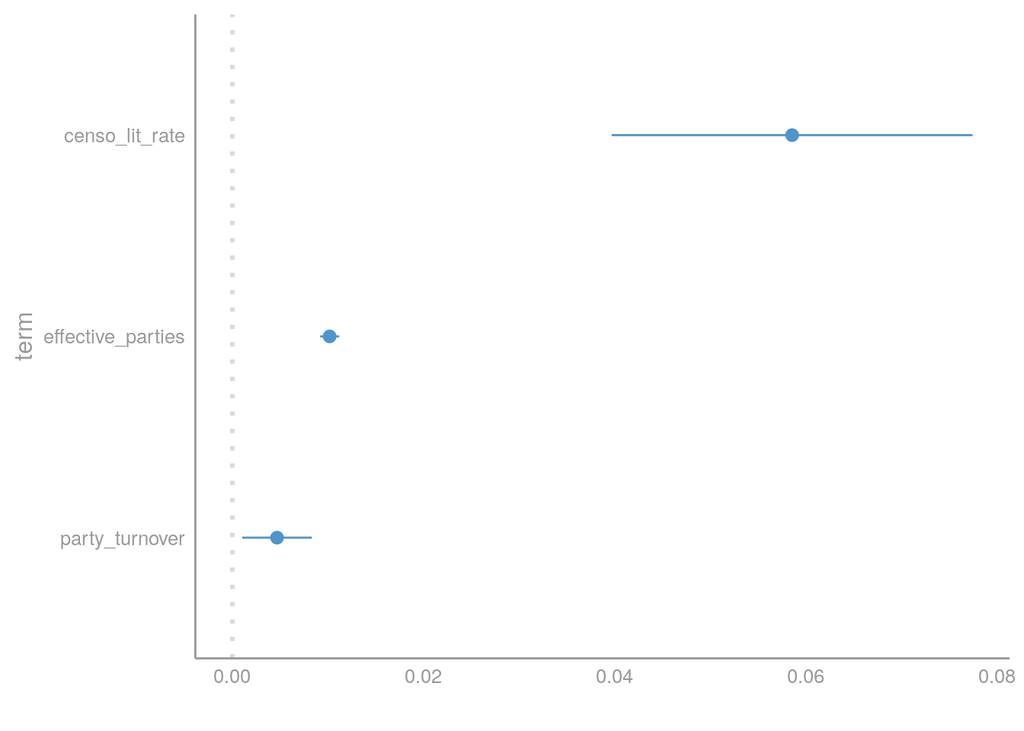

With respect to political variables, it is worthwhile noting that as the share of legislative seats controlled by the mayor increases, turnover decreases. Conversely, as the number of effective parties increase, staff turnover increases. It fits the broader story of the use of public sector jobs as an executive tool for legislative cooptation. I repeat the analysis with fixed effects for year and state.

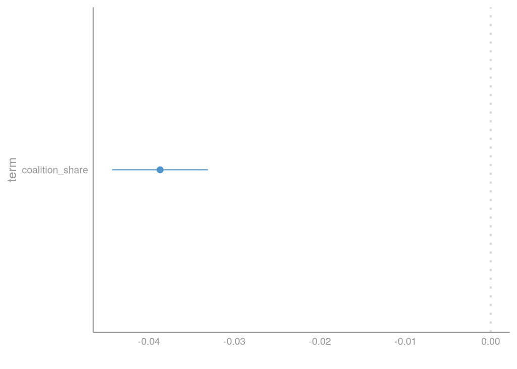

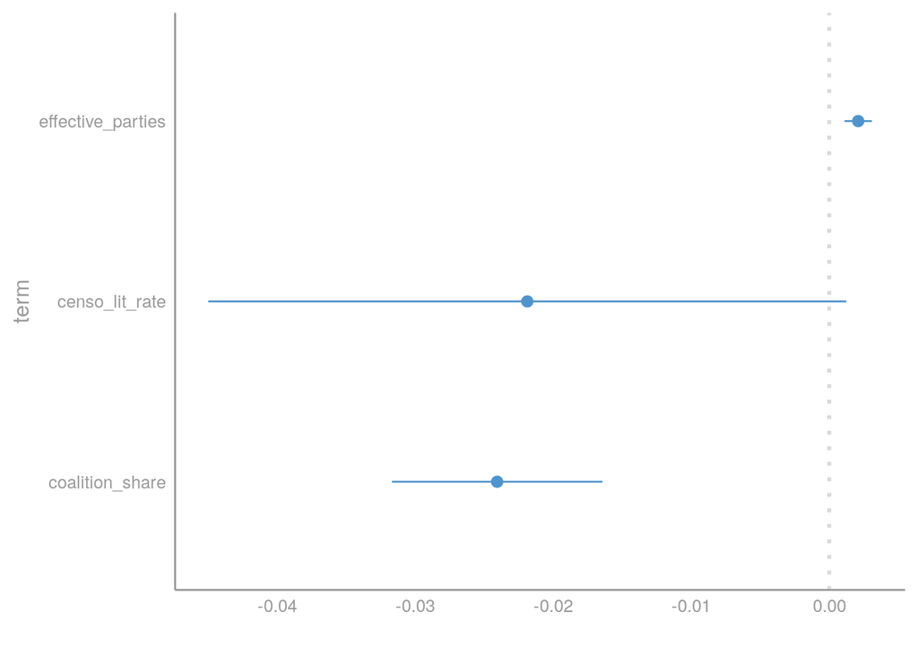

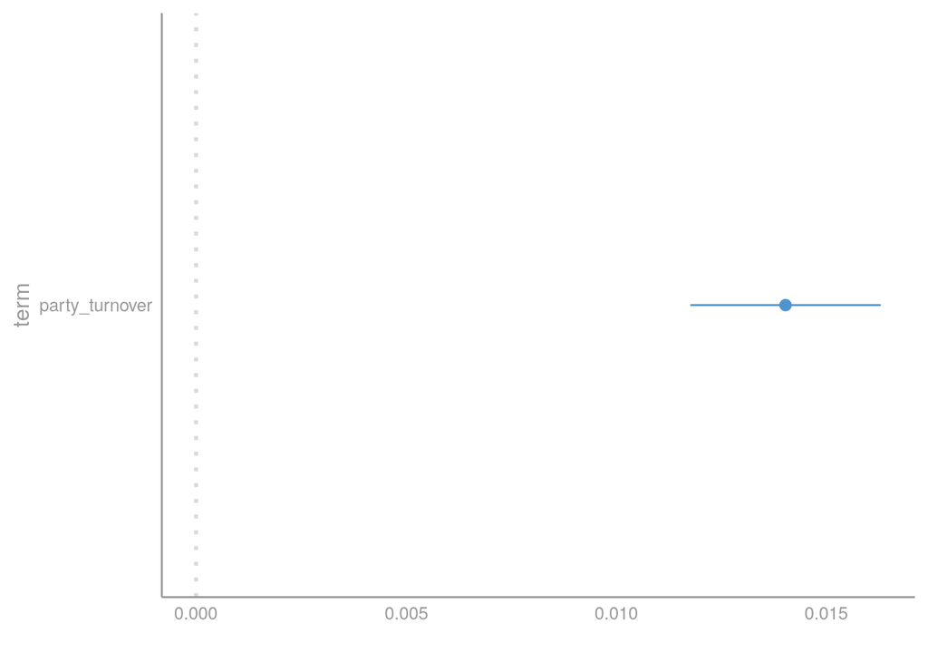

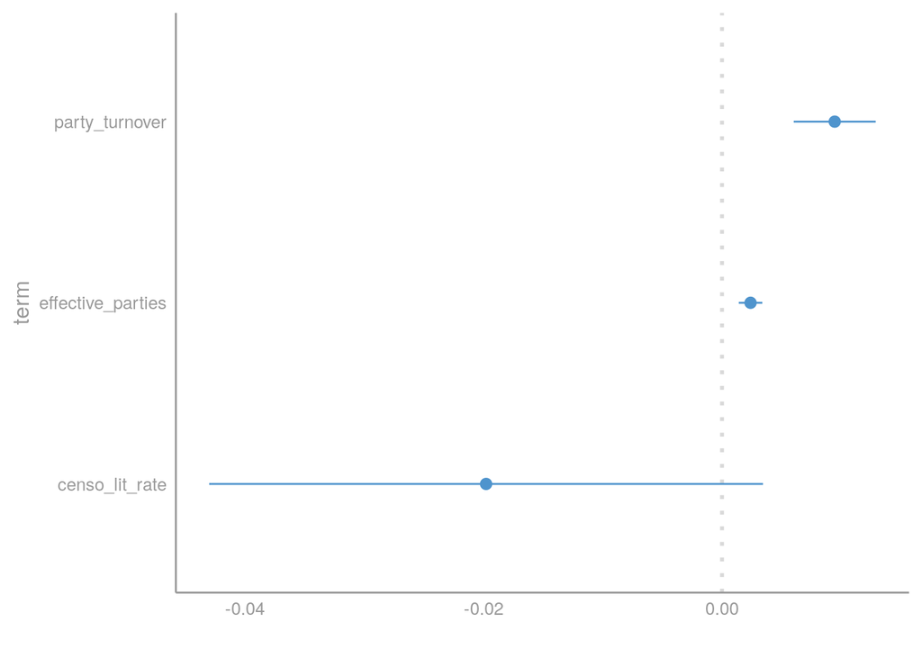

Substantively similar results to the ones in the simple OLS regression. Still find that coalition share is inversely related to the amount of turnover observed in the data. Not surprising that party turnover is associated with greater teacher turnover, similar to what is found by Toral (2019) and Akhtari et al. (2018).